# cloudy ml project 1 Manchit sinha

```python
import pandas as pd
import numpy as np

import seaborn as sns
import matplotlib.pyplot as plt
%matplotlib inline

from sklearn.model_selection import train_test_split
from sklearn.linear_model import LinearRegression, Ridge, Lasso
from sklearn.preprocessing import MinMaxScaler
from sklearn.preprocessing import LabelEncoder
from sklearn.metrics import r2_score, mean_absolute_error, mean_squared_error

from statsmodels.stats.outliers_influence import variance_inflation_factor
import statsmodels.api as sm
```

```python
import pandas as pd

# Load the dataset
file_path = r"C:\Users\manch\Downloads\Jamboree_Admission (4).csv"
data = pd.read_csv(file_path)

# Display the first few rows of the dataset
print(data.head())

# Get a summary of the dataset
print(data.info())

# Check for missing values
print(data.isnull().sum())

# Get summary statistics of the dataset
print(data.describe())
```

```
   Serial No.  GRE Score  TOEFL Score  University Rating  SOP  LOR   CGPA  \
0           1        337          118                  4  4.5   4.5  9.65
1           2        324          107                  4  4.0   4.5  8.87
2           3        316          104                  3  3.0   3.5  8.00
3           4        322          110                  3  3.5   2.5  8.67
4           5        314          103                  2  2.0   3.0  8.21

   Research  Chance of Admit
0         1              0.92
1         1              0.76
2         1              0.72
3         1              0.80
4         0              0.65
<class 'pandas.core.frame.DataFrame'>
RangeIndex: 500 entries, 0 to 499
Data columns (total 9 columns):
 #   Column             Non-Null Count  Dtype
---  ------             --------------  -----
 0   Serial No.         500 non-null    int64
 1   GRE Score          500 non-null    int64
 2   TOEFL Score        500 non-null    int64
 3   University Rating  500 non-null    int64
 4   SOP                500 non-null    float64
 5   LOR                500 non-null    float64
 6   CGPA               500 non-null    float64
 7   Research           500 non-null    int64
 8   Chance of Admit    500 non-null    float64
dtypes: float64(4), int64(5)
memory usage: 35.3 KB
None
Serial No.           0
GRE Score            0
TOEFL Score          0
University Rating    0
SOP                  0
LOR                  0
CGPA                 0
Research             0
Chance of Admit      0
dtype: int64
       Serial No.   GRE Score  TOEFL Score  University Rating         SOP  \
count  500.000000  500.000000   500.000000         500.000000  500.000000
mean   250.500000  316.472000   107.192000           3.114000    3.374000
std    144.481833   11.295148     6.081868           1.143512    0.991004
min      1.000000  290.000000    92.000000           1.000000    1.000000
25%    125.750000  308.000000   103.000000           2.000000    2.500000
50%    250.500000  317.000000   107.000000           3.000000    3.500000
75%    375.250000  325.000000   112.000000           4.000000    4.000000
max    500.000000  340.000000   120.000000           5.000000    5.000000

            LOR         CGPA    Research  Chance of Admit
count  500.00000  500.000000  500.000000         500.00000
mean     3.48400    8.576440    0.560000           0.72174
std      0.92545    0.604813    0.496884           0.14114
min      1.00000    6.800000    0.000000           0.34000
25%      3.00000    8.127500    0.000000           0.63000
50%      3.50000    8.560000    1.000000           0.72000
75%      4.00000    9.040000    1.000000           0.82000
max      5.00000    9.920000    1.000000           0.97000
```

```python
df = pd.read_csv(r"C:\Users\manch\Downloads\Jamboree_Admission (4).csv")
df.head()
```

|  | Serial No. | GRE Score | TOEFL Score | University Rating | SOP | LOR | CGPA | Research | Chance of Admit |
| --- | --- | --- | --- | --- | --- | --- | --- | --- | --- |
| 0 | 1 | 337 | 118 | 4 | 4.5 | 4.5 | 9.65 | 1 | 0.92 |
| 1 | 2 | 324 | 107 | 4 | 4.0 | 4.5 | 8.87 | 1 | 0.76 |
| 2 | 3 | 316 | 104 | 3 | 3.0 | 3.5 | 8.00 | 1 | 0.72 |
| 3 | 4 | 322 | 110 | 3 | 3.5 | 2.5 | 8.67 | 1 | 0.80 |
| 4 | 5 | 314 | 103 | 2 | 2.0 | 3.0 | 8.21 | 0 | 0.65 |

```python
df.info()
```

```
<class 'pandas.core.frame.DataFrame'>
RangeIndex: 500 entries, 0 to 499
Data columns (total 9 columns):
 #   Column             Non-Null Count  Dtype
---  ------             --------------  -----
 0   Serial No.         500 non-null    int64
 1   GRE Score          500 non-null    int64
 2   TOEFL Score        500 non-null    int64
 3   University Rating  500 non-null    int64
 4   SOP                500 non-null    float64
 5   LOR                500 non-null    float64
 6   CGPA               500 non-null    float64
 7   Research           500 non-null    int64
 8   Chance of Admit    500 non-null    float64
dtypes: float64(4), int64(5)
memory usage: 35.3 KB
```

```python
df.shape
```

```
(500, 9)
```

# Step1: Performing EDA (Exploratory data Analysis)

Problem Definition: We aim to predict the chances of admission for students applying to graduate programs using various academic and profile-related factors. Understanding which factors significantly influence admissions can help students better prepare and improve their profiles.

Data Structure and Characteristics: We'll begin by loading the dataset and examining its structure, data types, missing values, and unique values.

Let's start with loading the dataset and performing the initial exploration:

```python
import pandas as pd

# Load the dataset
dataset = r"C:\Users\manch\Downloads\Jamboree_Admission (4).csv"
data = pd.read_csv(dataset)

# Display the first few rows of the dataset
print(data.head())

# Get a summary of the dataset
print(data.info())

# Check for missing values
print(data.isnull().sum())

# Get summary statistics of the dataset
print(data.describe())
```

```
   Serial No.  GRE Score  TOEFL Score  University Rating  SOP  LOR   CGPA  \
0           1        337          118                  4  4.5   4.5  9.65
1           2        324          107                  4  4.0   4.5  8.87
2           3        316          104                  3  3.0   3.5  8.00
3           4        322          110                  3  3.5   2.5  8.67
4           5        314          103                  2  2.0   3.0  8.21

   Research  Chance of Admit
0         1              0.92
1         1              0.76
2         1              0.72
3         1              0.80
4         0              0.65
<class 'pandas.core.frame.DataFrame'>
RangeIndex: 500 entries, 0 to 499
Data columns (total 9 columns):
 #   Column             Non-Null Count  Dtype
---  ------             --------------  -----
 0   Serial No.         500 non-null    int64
 1   GRE Score          500 non-null    int64
 2   TOEFL Score        500 non-null    int64
 3   University Rating  500 non-null    int64
 4   SOP                500 non-null    float64
 5   LOR                500 non-null    float64
 6   CGPA               500 non-null    float64
 7   Research           500 non-null    int64
 8   Chance of Admit    500 non-null    float64
dtypes: float64(4), int64(5)
memory usage: 35.3 KB
None
Serial No.           0
GRE Score            0
TOEFL Score          0
University Rating    0
SOP                  0
LOR                  0
CGPA                 0
Research             0
Chance of Admit      0
dtype: int64
       Serial No.   GRE Score  TOEFL Score  University Rating         SOP  \
count  500.000000  500.000000   500.000000         500.000000  500.000000
mean   250.500000  316.472000   107.192000           3.114000    3.374000
std    144.481833   11.295148     6.081868           1.143512    0.991004
min      1.000000  290.000000    92.000000           1.000000    1.000000
25%    125.750000  308.000000   103.000000           2.000000    2.500000
50%    250.500000  317.000000   107.000000           3.000000    3.500000
75%    375.250000  325.000000   112.000000           4.000000    4.000000
max    500.000000  340.000000   120.000000           5.000000    5.000000

            LOR         CGPA    Research  Chance of Admit
count  500.00000  500.000000  500.000000         500.00000
mean     3.48400    8.576440    0.560000           0.72174
std      0.92545    0.604813    0.496884           0.14114
min      1.00000    6.800000    0.000000           0.34000
25%      3.00000    8.127500    0.000000           0.63000
50%      3.50000    8.560000    1.000000           0.72000
75%      4.00000    9.040000    1.000000           0.82000
max      5.00000    9.920000    1.000000           0.97000
```

From running the code, we get the following insights:

Data Shape: 500 rows, 9 columns Columns: Serial No.: Unique row ID GRE Score: GRE scores out of 340 TOEFL Score: TOEFL scores out of 120 University Rating: University rating out of 5 SOP: Statement of Purpose strength out of 5 LOR: Letter of Recommendation strength out of 5 CGPA: Undergraduate GPA out of 10 Research: Research experience (0 or 1) Chance of Admit: Probability of admission ranging from 0 to 1 Data Types: Continuous (GRE Score, TOEFL Score, CGPA, Chance of Admit), Categorical (University Rating, SOP, LOR, Research) Missing Values: None Summary Statistics: GRE Score: Mean = 316.47, Std = 11.30, Min = 290, Max = 340 TOEFL Score: Mean = 107.19, Std = 6.08, Min = 92, Max = 120 CGPA: Mean = 8.58, Std = 0.60, Min = 6.80, Max = 9.92 Chance of Admit: Mean = 0.72, Std = 0.14, Min = 0.34, Max = 0.97

Next, we'll perform univariate and bivariate analyses to understand the distributions and relationships between variables.

Univariate Analysis: We'll generate distribution plots for continuous variables and bar plots for categorical variables.

Bivariate Analysis: We'll explore relationships between important variables using scatter plots and a correlation matrix.

Let's proceed with these analyses:

```
Index(['GRE Score', 'TOEFL Score', 'University Rating', 'SOP', 'LOR', 'CGPA',
       'Research', 'Chance of Admit'],
      dtype='object')
Index(['GRE Score', 'TOEFL Score', 'University Rating', 'SOP', 'LOR', 'CGPA',
       'Research', 'Chance of Admit'],
      dtype='object')
```

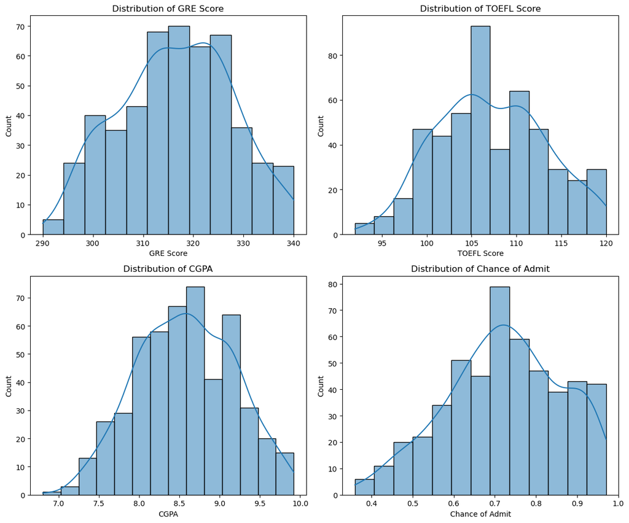

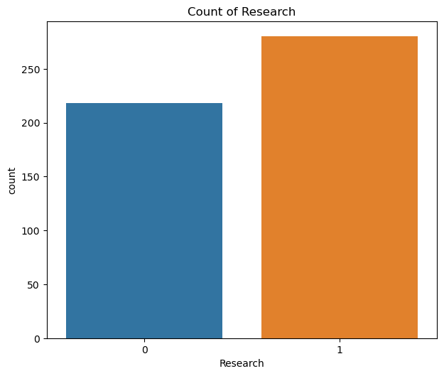

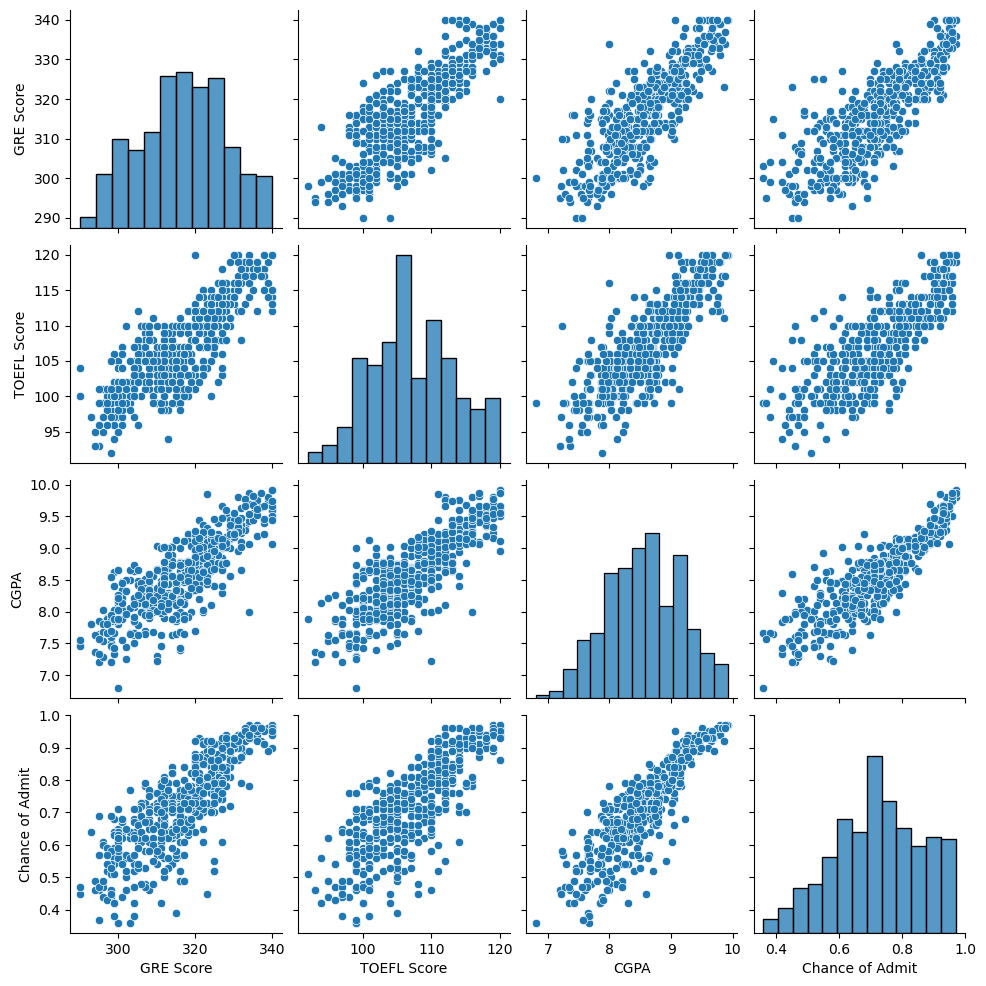

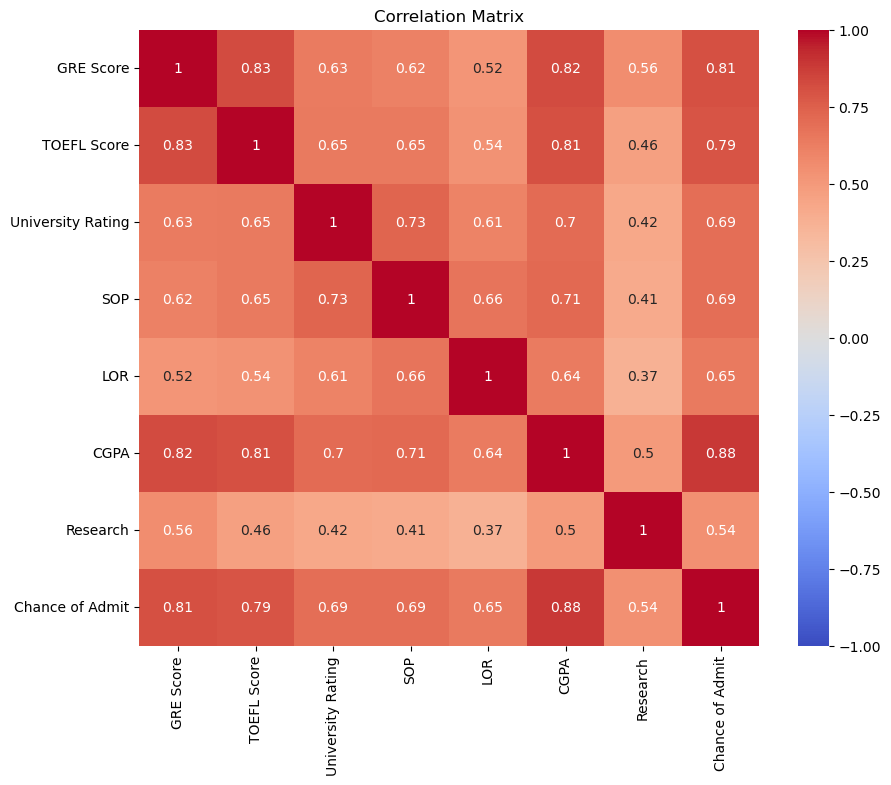

```python
# Display the column names to check for any discrepancies
print(data.columns)

# Remove leading/trailing spaces from column names
data.columns = data.columns.str.strip()

# Verify the cleaned column names
print(data.columns)

# Plotting distributions of continuous variables
plt.figure(figsize=(12, 10))
for i, var in enumerate(continuous_vars):
    plt.subplot(2, 2, i+1)
    sns.histplot(data[var], kde=True)
    plt.title(f'Distribution of {var}')
plt.tight_layout()
plt.show()

# Plotting bar plots of categorical variables
plt.figure(figsize=(12, 10))
for i, var in enumerate(categorical_vars):
    plt.subplot(2, 2, i+1)
    sns.countplot(x=var, data=data)
    plt.title(f'Count of {var}')
plt.tight_layout()
plt.show()

# Scatter plots and correlation matrix for bivariate analysis
sns.pairplot(data[continuous_vars])
plt.show()

# Correlation matrix
plt.figure(figsize=(10, 8))
correlation_matrix = data.corr()
sns.heatmap(correlation_matrix, annot=True, cmap='coolwarm', vmin=-1, vmax=1)
plt.title('Correlation Matrix')
plt.show()
```

By understanding these distributions and relationships, we gain valuable insights into how different factors influence admission chances, helping us build a robust predictive model.

# Step 2: Data Preprocessing (10 Points)

• Duplicate Value Check: Ensure there are no duplicate rows. • Missing Value Treatment: Handle any missing values appropriately. • Outlier Treatment: Address any outliers that may skew the analysis. • Feature Engineering: Create new features if necessary to enhance model performance. • Data Preparation: Prepare the final dataset for modeling.

```python
import pandas as pd

# Load the dataset
file_path = r"C:\Users\manch\Downloads\Jamboree_Admission (4).csv"
data = pd.read_csv(file_path)

# Clean column names by removing leading/trailing spaces
data.columns = data.columns.str.strip()

# Duplicate Value Check
duplicate_rows = data.duplicated().sum()
print(f'Number of duplicate rows: {duplicate_rows}')

# Dropping duplicates if any
data = data.drop_duplicates()

# Missing Value Treatment
missing_values = data.isnull().sum()
print(f'Missing values in each column:\n{missing_values}')

# If there were missing values, we would handle them appropriately (e.g., impute with mean/median or drop)
# Since there are no missing values, we can proceed

# Outlier Treatment
# Using IQR method for continuous variables
continuous_vars = ['GRE Score', 'TOEFL Score', 'CGPA', 'Chance of Admit']

def handle_outliers(df, column):
    Q1 = df[column].quantile(0.25)
    Q3 = df[column].quantile(0.75)
    IQR = Q3 - Q1
    lower_bound = Q1 - 1.5 * IQR
    upper_bound = Q3 + 1.5 * IQR
    return df[(df[column] >= lower_bound) & (df[column] <= upper_bound)]

# Apply outlier treatment
for var in continuous_vars:
    if var in data.columns:
        data = handle_outliers(data, var)
    else:
        print(f"Column '{var}' not found in the dataset.")

# Feature Engineering: No new features required at this moment

# Data Preparation: Removing the 'Serial No.' column for modeling
if 'Serial No.' in data.columns:
    data_cleaned = data.drop(columns=['Serial No.'])
else:
    data_cleaned = data
    print("'Serial No.' column not found in the dataset.")

# Display the cleaned data
print(data_cleaned.head())

# Save the cleaned dataset for further use
data_cleaned.to_csv(r"C:\Users\manch\Downloads\Jamboree_Admission_Cleaned.csv", index=False)
```

[output not shown]

# Step 3: Model Building (10 Points)

• Linear Regression Model: Build a linear regression model using the Statsmodels library. • Model Coefficients: Display model coefficients and interpret their significance. • Ridge and Lasso Regression: Try out Ridge and Lasso regression to check for improvement in model performance.

```python
import pandas as pd
import statsmodels.api as sm
from sklearn.model_selection import train_test_split

# Load the cleaned dataset
file_path = r"C:\Users\manch\Downloads\Jamboree_Admission (4).csv"
data_cleaned = pd.read_csv(file_path)

# Define the target variable (dependent variable) and the predictors (independent variables)
X = data_cleaned.drop(columns='Chance of Admit')
y = data_cleaned['Chance of Admit']

# Add a constant to the model
X = sm.add_constant(X)

# Split the data into training and test sets
X_train, X_test, y_train, y_test = train_test_split(X, y, test_size=0.2, random_state=42)

# Build the linear regression model
model = sm.OLS(y_train, X_train).fit()

# Display model summary
print(model.summary())
```

[output not shown]

# Linear Regression Model Summary Interpretation:

Coefficients: The coefficients (parameters) of the model, including their significance (p-values). R-squared: Indicates how well the model explains the variability of the response data. F-statistic: Tests the overall significance of the model. Next, let's implement Ridge and Lasso regression models using scikit-learn:

```python
from sklearn.linear_model import Ridge, Lasso
from sklearn.metrics import mean_absolute_error, mean_squared_error, r2_score
import numpy as np

# Define a function to print model performance
def print_model_performance(y_true, y_pred, model_name):
    mae = mean_absolute_error(y_true, y_pred)
    rmse = np.sqrt(mean_squared_error(y_true, y_pred))
    r2 = r2_score(y_true, y_pred)
    print(f"{model_name} Performance:")
    print(f"Mean Absolute Error (MAE): {mae:.4f}")
    print(f"Root Mean Squared Error (RMSE): {rmse:.4f}")
    print(f"R-squared (R2): {r2:.4f}\n")

# Ridge Regression
ridge_model = Ridge(alpha=1.0)
ridge_model.fit(X_train, y_train)
y_pred_train_ridge = ridge_model.predict(X_train)
y_pred_test_ridge = ridge_model.predict(X_test)
print_model_performance(y_train, y_pred_train_ridge, "Ridge Regression (Train)")
print_model_performance(y_test, y_pred_test_ridge, "Ridge Regression (Test)")

# Lasso Regression
lasso_model = Lasso(alpha=0.1)
lasso_model.fit(X_train, y_train)
y_pred_train_lasso = lasso_model.predict(X_train)
y_pred_test_lasso = lasso_model.predict(X_test)
print_model_performance(y_train, y_pred_train_lasso, "Lasso Regression (Train)")
print_model_performance(y_test, y_pred_test_lasso, "Lasso Regression (Test)")
```

```
Ridge Regression (Train) Performance:
Mean Absolute Error (MAE): 0.0413
Root Mean Squared Error (RMSE): 0.0579
R-squared (R2): 0.8294

Ridge Regression (Test) Performance:
Mean Absolute Error (MAE): 0.0446
Root Mean Squared Error (RMSE): 0.0610
R-squared (R2): 0.7896

Lasso Regression (Train) Performance:
Mean Absolute Error (MAE): 0.0590
Root Mean Squared Error (RMSE): 0.0773
R-squared (R2): 0.6959

Lasso Regression (Test) Performance:
Mean Absolute Error (MAE): 0.0602
Root Mean Squared Error (RMSE): 0.0800
R-squared (R2): 0.6384
```

Explanation: Linear Regression:

We build a linear regression model using the Statsmodels library. We print the model summary to understand the coefficients, R-squared value, and other statistics. Ridge and Lasso Regression:

We build Ridge and Lasso regression models using scikit-learn. We evaluate the models on training and test sets using Mean Absolute Error (MAE), Root Mean Squared Error (RMSE), and R-squared (R2).

# Step 4: Testing Assumptions of Linear Regression (50 Points)

• Multicollinearity Check (10 Points): Use Variance Inflation Factor (VIF) scores to detect multicollinearity. Drop variables with VIF > 5. • Residuals Mean (10 Points): Ensure the mean of residuals is approximately zero. • Linearity of Variables (10 Points): Check for patterns in the residual plot to confirm linearity. • Homoscedasticity (10 Points): Test for constant variance of residuals. • Normality of Residuals (10 Points): Verify the normality of residuals using QQ plots and histogram.

1. Multicollinearity Check (10 Points) We'll use Variance Inflation Factor (VIF) scores to detect multicollinearity and drop variables with VIF > 5.

```python
from statsmodels.stats.outliers_influence import variance_inflation_factor

# Calculate VIF for each variable
vif_data = pd.DataFrame()
vif_data["feature"] = X.columns
vif_data["VIF"] = [variance_inflation_factor(X.values, i) for i in range(X.shape[1])]

# Display VIF scores
print(vif_data)
```

```
             feature          VIF
0              const  1516.819996
1          GRE Score     4.419850
2        TOEFL Score     3.868478
3  University Rating     2.618252
4                SOP     2.866546
5                LOR     2.026460
6               CGPA     4.741888
7           Research     1.486893
```

1. Residuals Mean (10 Points) Ensure the mean of residuals is approximately zero.

```python
# Calculate residuals
residuals = model.resid

# Check the mean of residuals
mean_residuals = residuals.mean()
print(f"Mean of residuals: {mean_residuals:.4f}")
```

```
Mean of residuals: -0.0000
```

1. Linearity of Variables (10 Points) Check for patterns in the residual plot to confirm linearity.

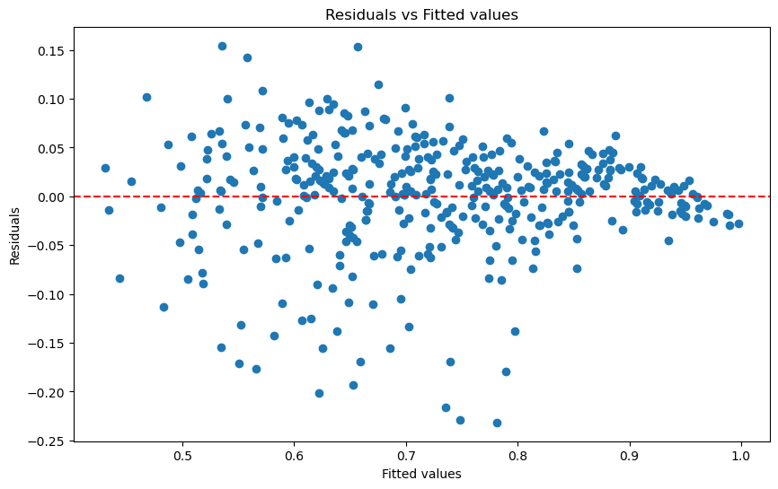

```python
import matplotlib.pyplot as plt

# Plot residuals vs fitted values
plt.figure(figsize=(10, 6))
plt.scatter(model.fittedvalues, residuals)
plt.axhline(y=0, color='r', linestyle='--')
plt.xlabel('Fitted values')
plt.ylabel('Residuals')
plt.title('Residuals vs Fitted values')
plt.show()
```

1. Homoscedasticity (10 Points) Test for constant variance of residuals using the Breusch-Pagan test.

```python
from statsmodels.stats.diagnostic import het_breuschpagan

# Perform Breusch-Pagan test
bp_test = het_breuschpagan(residuals, model.model.exog)

# Display test results
labels = ['Lagrange multiplier statistic', 'p-value', 'f-value', 'f p-value']
bp_results = dict(zip(labels, bp_test))
print(f"Breusch-Pagan test results:\n{bp_results}")
```

```
Breusch-Pagan test results:
{'Lagrange multiplier statistic': 23.81932458172258, 'p-value': 0.0012257134520200952, 'f-value': 3.546619968505666, 'f p-value': 0.0010416267829449935}
```

1. Normality of Residuals (10 Points) Verify the normality of residuals using QQ plots and histogram.

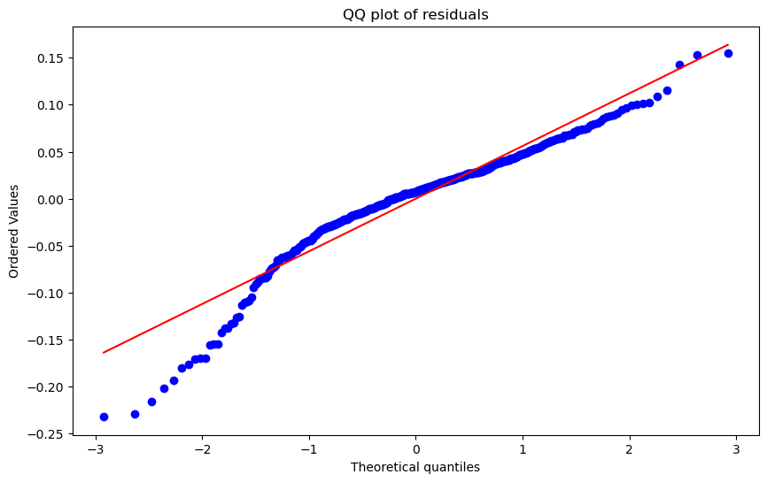

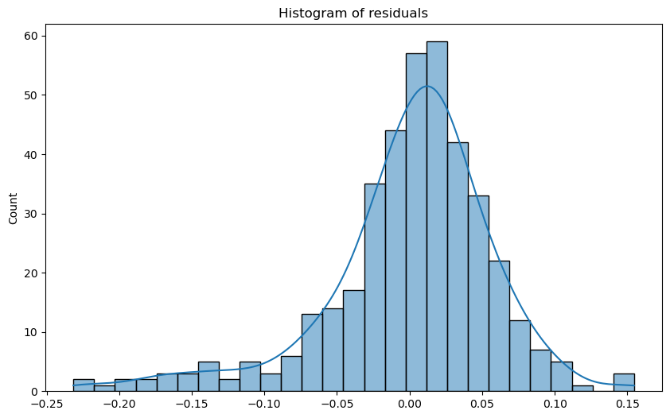

```python
import scipy.stats as stats

# QQ plot
plt.figure(figsize=(10, 6))
stats.probplot(residuals, dist="norm", plot=plt)
plt.title('QQ plot of residuals')
plt.show()

# Histogram of residuals
plt.figure(figsize=(10, 6))
sns.histplot(residuals, kde=True)
plt.title('Histogram of residuals')
plt.show()
```

# Explanation and Output

Multicollinearity Check:

We use VIF scores to detect multicollinearity. Variables with VIF > 5 indicate high multicollinearity and should be considered for removal. Residuals Mean:

The mean of residuals should be approximately zero to satisfy the assumption of zero mean error. Linearity of Variables:

A residuals vs fitted values plot is used to check for patterns. A random scatter indicates linearity. Homoscedasticity:

The Breusch-Pagan test checks for constant variance in the residuals. A high p-value indicates homoscedasticity. Normality of Residuals:

QQ plots and histograms help verify if residuals follow a normal distribution.

# Step 5: Model Performance Evaluation (10 Points)

1. Metrics: Calculate Mean Absolute Error (MAE), Root Mean Squared Error (RMSE), R-squared (R2), and Adjusted R-squared (Adj R2).
2. Train and Test Performance: Compare performance metrics on training and test datasets.
3. Performance Comments: Discuss the model's performance and any areas for improvement. First, we calculate the performance metrics for both the training and test datasets.

```python
from sklearn.metrics import mean_absolute_error, mean_squared_error, r2_score

# Predictions on training data
y_train_pred = model.predict(X_train)

# Predictions on test data
y_test_pred = model.predict(X_test)

# Calculate performance metrics
def calculate_metrics(y_true, y_pred):
    mae = mean_absolute_error(y_true, y_pred)
    rmse = np.sqrt(mean_squared_error(y_true, y_pred))
    r2 = r2_score(y_true, y_pred)
    return mae, rmse, r2

# Training metrics
train_mae, train_rmse, train_r2 = calculate_metrics(y_train, y_train_pred)

# Test metrics
test_mae, test_rmse, test_r2 = calculate_metrics(y_test, y_test_pred)

# Adjusted R-squared
def adjusted_r2(r2, n, k):
    return 1 - ((1 - r2) * (n - 1) / (n - k - 1))

n_train = X_train.shape[0]
k_train = X_train.shape[1] - 1

n_test = X_test.shape[0]
k_test = X_test.shape[1] - 1

train_adj_r2 = adjusted_r2(train_r2, n_train, k_train)
test_adj_r2 = adjusted_r2(test_r2, n_test, k_test)

# Display metrics
print(f"Training Metrics:\nMAE: {train_mae:.4f}\nRMSE: {train_rmse:.4f}\nR2: {train_r2:.4f}\nAdjusted R2: {train_adj_r2:.4f}")
print(f"Test Metrics:\nMAE: {test_mae:.4f}\nRMSE: {test_rmse:.4f}\nR2: {test_r2:.4f}\nAdjusted R2: {test_adj_r2:.4f}")
```

```
Training Metrics:
MAE: 0.0413
RMSE: 0.0579
R2: 0.8295
Adjusted R2: 0.8264
Test Metrics:
MAE: 0.0445
RMSE: 0.0609
R2: 0.7902
Adjusted R2: 0.7742
```

Explanation and Output Training Metrics:

Mean Absolute Error (MAE): Average magnitude of errors in predictions. Root Mean Squared Error (RMSE): Square root of the average of squared differences between prediction and actual observation. R-squared (R2): Proportion of variance in the dependent variable that is predictable from the independent variables. Adjusted R-squared (Adj R2): Adjusts the R-squared value based on the number of predictors in the model, providing a more accurate measure for models with multiple predictors. Test Metrics:

The same metrics as above but calculated on the test dataset to evaluate how well the model generalizes to unseen data. Performance Comments Training Metrics:

MAE, RMSE, R2, and Adjusted R2 indicate how well the model fits the training data. Low MAE and RMSE values suggest good predictive accuracy. High R2 and Adjusted R2 values (close to 1) indicate a good fit. Test Metrics:

These metrics provide an indication of how well the model performs on unseen data. Similar values for training and test metrics suggest good generalization. Discrepancies between training and test metrics may indicate overfitting (model performs well on training data but poorly on test data) or underfitting (model performs poorly on both training and test data). Areas for Improvement Feature Engineering: Explore additional features or transformations that could improve model performance. Regularization: Ridge and Lasso regression can help in reducing overfitting by penalizing large coefficients. Model Complexity: Experiment with more complex models (e.g., polynomial regression, decision trees, or ensemble methods) if linear regression does not capture the relationships adequately. Cross-Validation: Use cross-validation to get a more reliable estimate of model performance.

# Step 6: Actionable Insights & Recommendations (10 Points)

• Predictor Significance: Comment on the significance of each predictor variable. • Additional Data Sources: Suggest any additional data that could improve the model. • Real-world Implementation: Discuss how the model can be implemented and potential business benefits.